# 2 Variable Inference

```r
library(tidyverse)
library(gt)
library(readxl)
library(modeldata)
```

## Question 1:

Null (Ho): Mean bill length is the same across species

Alternative (Ha): mean bill length is not the same across species

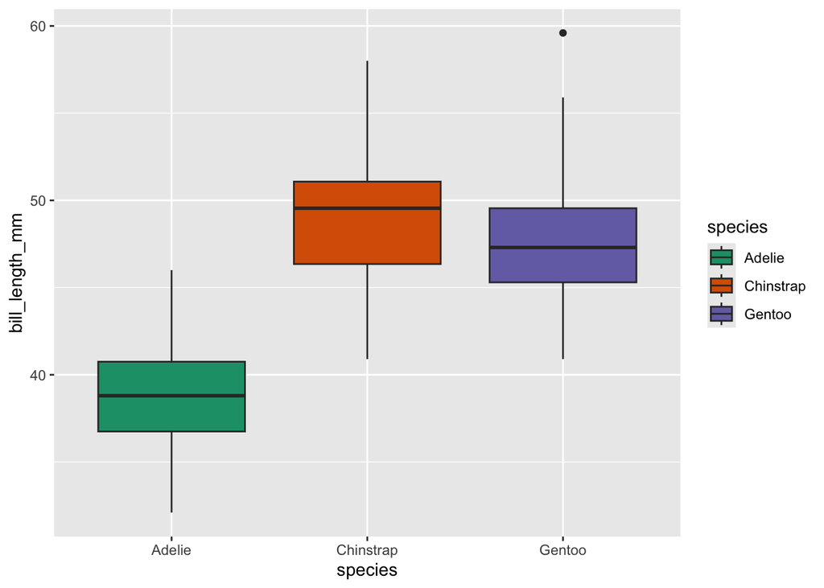

```r
ggplot(penguins,
       aes(x = species,
           y = bill_length_mm,
           fill = species)) +
  geom_boxplot() +
  scale_fill_brewer(palette = "Dark2")
```

```r
bill_model <- aov(bill_length_mm ~ species,
                  data = penguins)

summary(bill_model)
```

```
             Df Sum Sq Mean Sq F value Pr(>F)
species       2   7194    3597   410.6 <2e-16 ***
Residuals   339   2970       9
---
Signif. codes:  0 '***' 0.001 '**' 0.01 '*' 0.05 '.' 0.1 ' ' 1
2 observations deleted due to missingness
```

Extremely statistically significant Pvalue, so we reject the null, and conclude beyond a resonable doubt that they do not have the same average bill length

```r
bill_tukey <- TukeyHSD(bill_model)
bill_tukey
```

```
  Tukey multiple comparisons of means
    95% family-wise confidence level

Fit: aov(formula = bill_length_mm ~ species, data = penguins)

$species
                      diff       lwr        upr     p adj
Chinstrap-Adelie 10.042433  9.024859 11.0600064 0.0000000
Gentoo-Adelie     8.713487  7.867194  9.5597807 0.0000000
Gentoo-Chinstrap -1.328945 -2.381868 -0.2760231 0.0088993
```

## Question 2:

Null (Ho): Sex and species are independent (i.e., each species has the same male/female proportions).

Alternative (Ha): Sex and species are not independent (i.e., proportions differ by species)

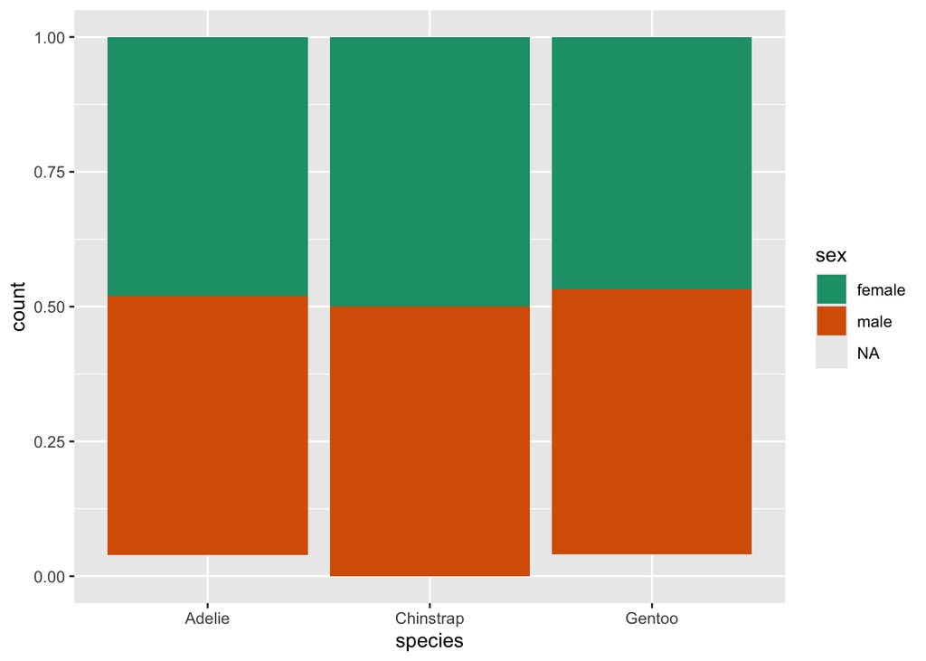

```r
ggplot(penguins,
       aes(x = species,
           fill = sex,
           )) +
  geom_bar(position = "fill") +
    scale_fill_brewer(palette = "Dark2")
```

```r
penguin_sex <- table(penguins$sex,
                     penguins$species)

chisq.test(penguin_sex)
```

```
    Pearson's Chi-squared test

data:  penguin_sex
X-squared = 0.048607, df = 2, p-value = 0.976
```

## Question 3:

Null (Ho): Mean body mass is the same across sexes

Alternative (Ha): mean body mass is not the same across sexes

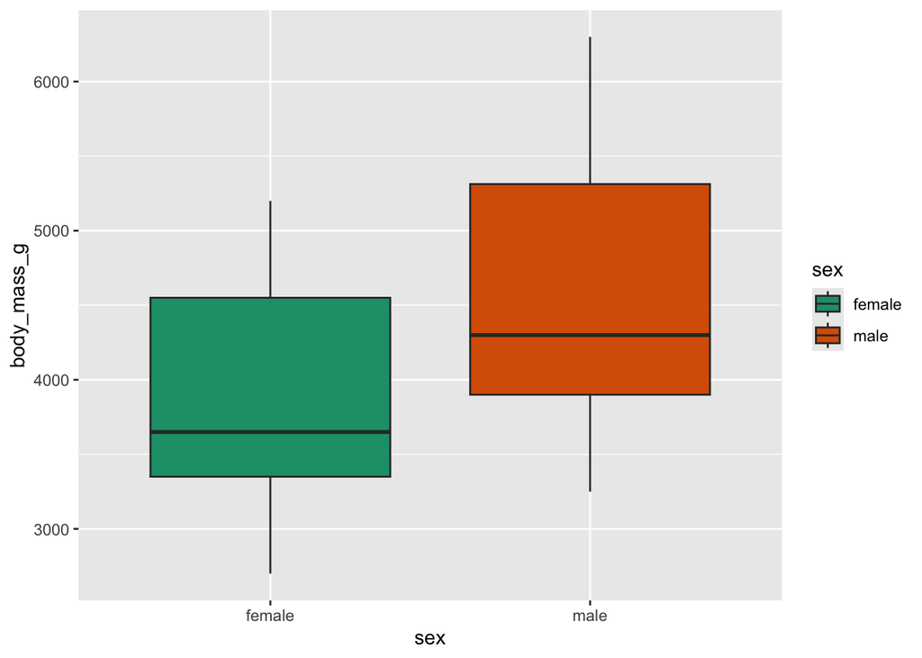

```r
penguins <- penguins %>%
  filter(!is.na(body_mass_g), !is.na(sex))

#| warning: false
ggplot(penguins,
       aes(x = sex,
           y = body_mass_g,
           fill = sex)) +
  geom_boxplot() +
  scale_fill_brewer(palette = "Dark2")
```

```r
sex_t_test <- t.test(body_mass_g ~ sex,
                     data = penguins)

sex_t_test
```

```
    Welch Two Sample t-test

data:  body_mass_g by sex
t = -8.5545, df = 323.9, p-value = 4.794e-16
alternative hypothesis: true difference in means between group female and group male is not equal to 0
95 percent confidence interval:
 -840.5783 -526.2453
sample estimates:
mean in group female   mean in group male
            3862.273             4545.685
```

pvalue is about as close to 0 as you can get, so we reject Ho and conclude that mean body mass is not the same across sexes

## Question 4

Null (Ho): Bill length and bill depth are independent

Alternative (Ha): Bill length and bill depth are not independent

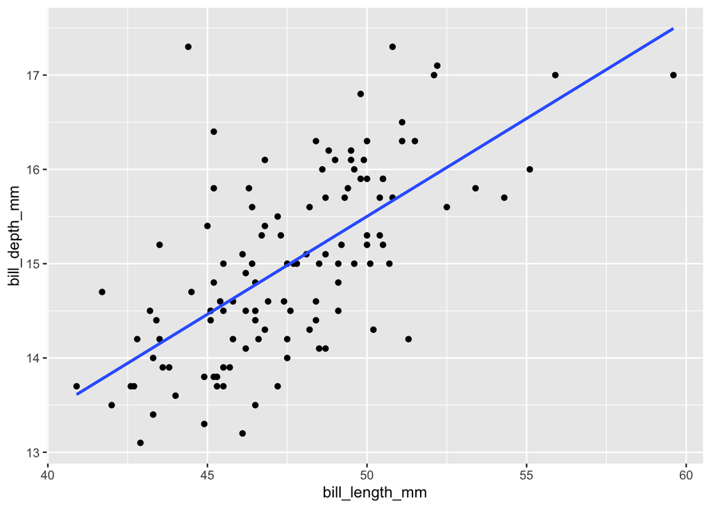

```r
gentoo <- penguins %>%
  filter(species == "Gentoo",
         !is.na(bill_length_mm),
         !is.na(bill_depth_mm))

ggplot(gentoo,
       aes(x = bill_length_mm,
           y = bill_depth_mm)) +
  geom_point() +
  geom_smooth(method = "lm", se = FALSE)
```

```r
lm(bill_depth_mm ~ bill_length_mm,
   data = gentoo)
```

```
Call:
lm(formula = bill_depth_mm ~ bill_length_mm, data = gentoo)

Coefficients:
   (Intercept)  bill_length_mm
        5.1210          0.2076
```

Equation is 5.1210 + .2076*(bill_length_mm)

```r
bill_model_2 <- lm(bill_depth_mm ~ bill_length_mm,
   data = gentoo)

summary(bill_model_2)
```

```
Call:
lm(formula = bill_depth_mm ~ bill_length_mm, data = gentoo)

Residuals:
     Min       1Q   Median       3Q      Max
-1.57143 -0.52974 -0.04479  0.45417  2.96109

Coefficients:
               Estimate Std. Error t value Pr(>|t|)
(Intercept)      5.1210     1.0583   4.839 4.02e-06 ***
bill_length_mm   0.2076     0.0222   9.352 7.34e-16 ***
---
Signif. codes:  0 '***' 0.001 '**' 0.01 '*' 0.05 '.' 0.1 ' ' 1

Residual standard error: 0.7491 on 117 degrees of freedom
Multiple R-squared:  0.4277,    Adjusted R-squared:  0.4229
F-statistic: 87.45 on 1 and 117 DF,  p-value: 7.337e-16
```

pvalue basically 0, is statistically significant, reject Ho

## Question 5:

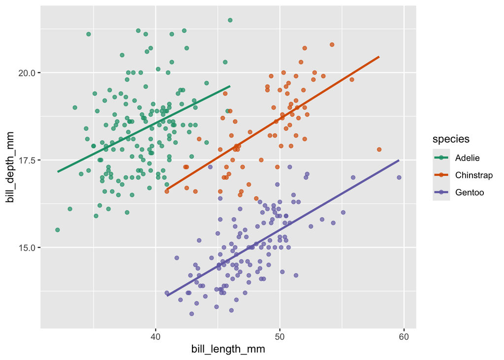

```r
penguins_clean <- penguins |>
  filter(!is.na(bill_length_mm), !is.na(bill_depth_mm), !is.na(species))

ggplot(penguins_clean, aes(x = bill_length_mm, y = bill_depth_mm, color = species)) +
  geom_point(alpha = 0.7) +
  geom_smooth(method = "lm", se = FALSE) +
  scale_color_brewer(palette = "Dark2")
```

```r
lm_species_model <- lm(bill_depth_mm ~ bill_length_mm * species, data = penguins)
summary(lm_species_model)
```

```
Call:
lm(formula = bill_depth_mm ~ bill_length_mm * species, data = penguins)

Residuals:
    Min      1Q  Median      3Q     Max
-2.6574 -0.6559 -0.0483  0.5203  3.4990

Coefficients:
                                Estimate Std. Error t value Pr(>|t|)
(Intercept)                     11.48771    1.15987   9.904  < 2e-16 ***
bill_length_mm                   0.17668    0.02981   5.928 7.79e-09 ***
speciesChinstrap                -3.91857    2.06731  -1.895   0.0589 .
speciesGentoo                   -6.36675    1.77990  -3.577   0.0004 ***
bill_length_mm:speciesChinstrap  0.04553    0.04594   0.991   0.3224
bill_length_mm:speciesGentoo     0.03093    0.04112   0.752   0.4525
---
Signif. codes:  0 '***' 0.001 '**' 0.01 '*' 0.05 '.' 0.1 ' ' 1

Residual standard error: 0.9556 on 327 degrees of freedom
Multiple R-squared:  0.7681,    Adjusted R-squared:  0.7645
F-statistic: 216.6 on 5 and 327 DF,  p-value: < 2.2e-16
```

Not exactly sure how to interpre this data.